# R Notebook

مقدار‌های مخدوش گزارش شده‌اند. دو مقدار مخدوش به صورت نوشته فارسی هم در ستون های تابستان ۹۷ و پاییز ۹۱ به صورت دستی اصلاح شدندو داده‌های تک مقدار صفر هم به صورت دستی خط تیره گذاشته شدند.

۶ ستون آخر را که داده‌های مخدوش زیادی داشتند از دیتا حذف میکنیم و داده‌های دیگر را با توجه به ندانستن کاربرد دیتاست خالی میگذاریم. در حالت کلی پر کردن این داده‌ها با مقادیر میانگین یا میانه میتواند باعث ایجاد خطا شود و در نظر نگرفتن مقادیر بهتر است.

```r
library(readxl)
library(writexl)
df = readxl::read_excel("dataset3.xlsx",sheet = "Sheet1", range = "A1:AT25")
```

```
* `` -> ...4
* `` -> ...5
* `` -> ...6
* `` -> ...8
* `` -> ...9
* ...
```

```r
df = df[-c(1), ]
for (col in 2:ncol(df)) {
  print(sum(unlist(lapply(lapply(df[, col], as.numeric), is.na))))
}
```

```
[1] 0
[1] 0
[1] 0
```

```
[1] 2
[1] 0
[1] 0
[1] 0
[1] 0
[1] 0
[1] 0
[1] 0
```

```
[1] 1
```

```
[1] 2
[1] 0
[1] 0
[1] 0
[1] 0
[1] 0
[1] 0
[1] 0
[1] 0
[1] 0
[1] 0
[1] 0
[1] 0
[1] 0
[1] 0
[1] 0
[1] 0
[1] 0
[1] 0
[1] 0
[1] 0
[1] 0
```

```
[1] 1
```

```
[1] 1
```

```
[1] 4
```

```
[1] 4
```

```
[1] 6
```

```
[1] 13
```

```
[1] 9
```

```
[1] 19
```

```
[1] 18
[1] 19
[1] 8
```

```r
df = df[-c(41:46)]
#View(df)
df = as.data.frame(sapply(df, as.numeric))
write_xlsx(x=df, "dataset_modified.xlsx")
```

```r
df = readxl::read_excel("dataset_modified.xlsx",sheet = "Sheet1", range = "A1:AN24")
df = df[-c(1)]
df = t(df)
v2 = rev(df[, 2])
v1 = seq(7,45,1)

data = data.frame(v1, v2, stringsAsFactors = F)
#View(data)
model <- lm(v2~v1)
model$coefficients
```

```
(Intercept)          v1
 -98302.771    8610.523
```

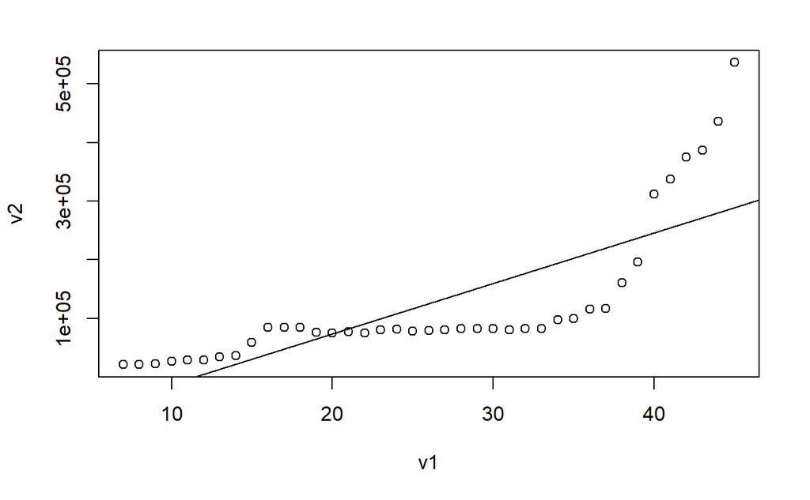

```r
library(ggplot2)
plot(v2~v1, data)
abline(model)
```

```r
df = df[, -c(1)]
#View(df)
price = vector()
time = vector()
region = vector()
for (i in seq(1:22)) {
  price = c(price, df[,i])
  time = c(time, seq(45,7,-1))
  region = c(region, rep(i, 39))
}
data = data.frame(region, time, price)
#View(data)
model <- lm(price~time+region)
model$coefficients
```

```
(Intercept)        time      region
  18271.849    3584.700   -4661.963
```

```r
price = vector()
time = vector()
region = vector()
for (i in seq(1:22)) {
  price = c(price, df[,i])
  time = c(time, seq(45,7,-1))
  region = c(region, rep(i, 39))
}

data = data.frame(region, time, price)
data$price <- as.numeric(gsub("\\.", "", data$price))
#View(data)
model <- lm(data$price~data$time+data$region)
summary(model)
```

```
Call:
lm(formula = data$price ~ data$time + data$region)

Residuals:
       Min         1Q     Median         3Q        Max
-5.051e+14 -1.263e+14 -5.510e+13  1.268e+14  7.816e+14

Coefficients:
              Estimate Std. Error t value Pr(>|t|)
(Intercept)  3.822e+14  2.487e+13  15.368  < 2e-16 ***
data$time    3.649e+12  7.191e+11   5.074  4.8e-07 ***
data$region -1.179e+13  1.256e+12  -9.384  < 2e-16 ***
---
Signif. codes:  0 ‘***’ 0.001 ‘**’ 0.01 ‘*’ 0.05 ‘.’ 0.1 ‘ ’ 1

Residual standard error: 2.306e+14 on 834 degrees of freedom
  (21 observations deleted due to missingness)
Multiple R-squared:  0.119, Adjusted R-squared:  0.1169
F-statistic: 56.31 on 2 and 834 DF,  p-value: < 2.2e-16
```

```r
mat <- matrix(0, nrow=858,ncol=23)
for (i in seq(2:21)) {
  beg = i * 39 + 1
  end = beg + 38
  mat[beg:end, i+1] = 1
}
data = data.frame(mat, time, price)
#View(data)
lm = lm(price~., data)
model$coefficients
```

```
  (Intercept)     data$time   data$region
 3.822180e+14  3.649004e+12 -1.178998e+13
```

```r
#View(data)
summary(lm)
```

```
Call:
lm(formula = price ~ ., data = data)

Residuals:
   Min     1Q Median     3Q    Max
-81309 -30326  -8316  18695 381606

Coefficients: (3 not defined because of singularities)
            Estimate Std. Error t value Pr(>|t|)
(Intercept)    -7418       6871  -1.080  0.28060
X1                NA         NA      NA       NA
X2             31550       9672   3.262  0.00115 **
X3             46916       9672   4.851 1.47e-06 ***
X4             -2792       9672  -0.289  0.77288
X5            -14258       9672  -1.474  0.14080
X6             20671       9756   2.119  0.03442 *
X7             -8532       9672  -0.882  0.37794
X8            -18987       9672  -1.963  0.04996 *
X9            -50254      10035  -5.008 6.75e-07 ***
X10           -45794       9672  -4.735 2.58e-06 ***
X11           -46894       9672  -4.849 1.49e-06 ***
X12           -51909       9672  -5.367 1.04e-07 ***
X13           -28663       9672  -2.964  0.00313 **
X14           -39227       9672  -4.056 5.47e-05 ***
X15           -55751       9672  -5.764 1.16e-08 ***
X16           -55851       9939  -5.619 2.63e-08 ***
X17           -65452      10038  -6.521 1.23e-10 ***
X18           -63664       9756  -6.525 1.19e-10 ***
X19           -62822      10136  -6.198 9.06e-10 ***
X20           -66839       9672  -6.911 9.71e-12 ***
X21           -51679       9936  -5.201 2.51e-07 ***
X22               NA         NA      NA       NA
X23               NA         NA      NA       NA
time            3607        154  23.428  < 2e-16 ***
---
Signif. codes:  0 ‘***’ 0.001 ‘**’ 0.01 ‘*’ 0.05 ‘.’ 0.1 ‘ ’ 1

Residual standard error: 49320 on 815 degrees of freedom
  (21 observations deleted due to missingness)
Multiple R-squared:  0.5262,    Adjusted R-squared:  0.514
F-statistic:  43.1 on 21 and 815 DF,  p-value: < 2.2e-16
```

قسمت دوم با توجه به نتایج به دست آمده به مراتب ارور‌های کمتری دارد و در نتیجه روش مناسب‌تری ست.

یکی از دلایل مهم آن میتواند نامرتبط بودن شماره محله به قیمت آن باشد. زیرا منطقه ای که خانه‌های با قیمت بالاتری دارد لزوما شماره بالاتری به آن داده نشده است. در واقع شماره گذاری محله ها کاملا مستقل از قیمت صورت گرفته.

```r
df = t(df)
X = df[, 22]
Y = df[, 23]
X <- as.numeric(gsub("\\.", "", X))
Y <- as.numeric(gsub("\\.", "", Y))
mean_x = mean(X)
mean_y = mean(Y)
mean_diff = mean_x - mean_y

sum_x = 0
for (variable in X) {
  sum_x = sum_x + (variable - mean_x) ** 2
}
sum_y = 0
for (variable in Y) {
  sum_y = sum_y + (variable - mean_y) ** 2
}
n = length(df[, 22])

sp = sqrt((sum_x + sum_y) / (n + n - 2))

t <- (mean_diff)/(sp/sqrt(n) + sp/sqrt(n))
p_value = 2 * pt(-abs(t),df=n + n -2)

mean_x
```

```
[1] 4.01349e+14
```

```r
mean_y
```

```
[1] 4.02242e+14
```

```r
sp
```

```
[1] 2.259215e+14
```

```r
p_value
```

```
[1] 0.992648
```

```r
t.test(X, Y)
```

```
    Welch Two Sample t-test

data:  X and Y
t = -0.013109, df = 41.977, p-value = 0.9896
alternative hypothesis: true difference in means is not equal to 0
95 percent confidence interval:
 -1.383626e+14  1.365767e+14
sample estimates:
  mean of x   mean of y
4.01349e+14 4.02242e+14
```

```r
Z = X - Y
mean_z = mean(Z)
var_z = var(Z)
t <- (mean_z)/(sqrt(var_z/n))
p_value = 2*pt(-abs(t),df=n-1)

mean_z
```

```
[1] -892956868824
```

```r
var_z
```

```
[1] 4.936461e+25
```

```r
p_value
```

```
[1] 0.5574664
```

```r
t.test(Z)
```

```
    One Sample t-test

data:  Z
t = -0.59612, df = 21, p-value = 0.5575
alternative hypothesis: true mean is not equal to 0
95 percent confidence interval:
 -4.008109e+12  2.222195e+12
sample estimates:
    mean of x
-892956868824
```

مقدار پی ولیدهای به دست آمده بزرگ است در نتیجه نمیتوانیم فرض صفر را رد کنیم.

روش اول بهتر است و پی ولیو بیشتری دارد. همچنین جفت در نظر گرفتن داده ها میتواند تاثیراث دیگری را وارد مسئله کند و وابستگی‌هایی را ایجاد کند. مثلا وابستگی به دانشجو‌ها. اما با جفت نبودن این تاثیرات مختلف را حذف میکنیم و خود امتحان ها را مقایسه میکنیم.